# Reproducible Research: Peer Assessment 1

## Loading and preprocessing the data

First, clean the working environment:

```r
rm(list=ls(all=TRUE))
```

Next, download the data:

```r
datafile <- "activity.zip"
if(!file.exists(datafile)){
    url <- "https://d396qusza40orc.cloudfront.net/repdata%2Fdata%2Factivity.zip"
    download.file(
        url,
        destfile = datafile,
        method = "curl",
        quiet = TRUE
    )
    unzip(
        zipfile = datafile
    )
}
```

Data description, from course website, as follows: > This assignment makes use of data from a personal activity monitoring device. This device collects data at 5 minute intervals through out the day. The data consists of two months of data from an anonymous individual collected during the months of October and November, 2012 and include the number of steps taken in 5 minute intervals each day.

Variables included in this dataset:

1. **steps**: Number of steps taking in a 5-minute interval (missing values are coded as NA)
2. **date**: The date on which the measurement was taken in YYYY-MM-DD format
3. **interval**: Identifier for the 5-minute interval in which measurement was taken

This dataset is stored in a comma-separated-value (CSV) file and with a total of 17,568 observations.

Next, read this data into a dataframe:

```r
if(!file.exists("activity.csv")){
  unzip(
    zipfile = datafile
  )
}
activity<-read.csv(
  "activity.csv",
  header = TRUE
)
totalSteps <- aggregate(
    steps ~ date,
    data = activity,
    sum,
    na.rm = TRUE
)
```

Aggregate relevant data in *totalSteps*.

## What is mean total number of steps taken per day?

> Make a histogram of the total number of steps taken daily.

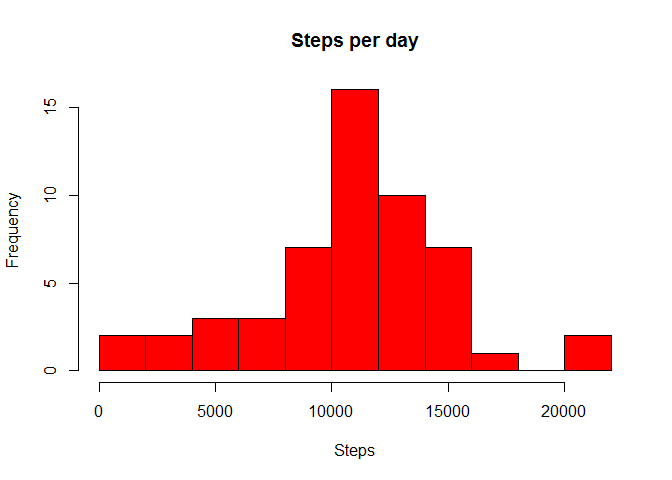

```r
hist(
  totalSteps$steps,
  main = "Steps per day",
  xlab = "Steps",
  col = "red",
  breaks = 8
)
```

```r
meansteps <- mean(totalSteps$steps)
mediansteps <- median(totalSteps$steps)
```

## What is the average daily activity pattern?

> Make a time series plot (type `l`) of the five minute interval along the x-axis and the average number of steps taken, averaged across all days along the y-axis.

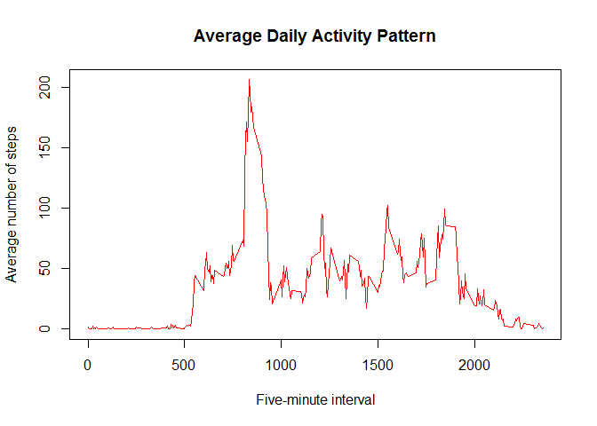

```r
stepsInterval <- aggregate(
    steps ~ interval,
    data = activity,
    mean,
    na.rm = TRUE
)
plot(
    steps ~ interval,
    data = stepsInterval,
    col = "red",
    xlab = "Five-minute interval",
    ylab = "Average number of steps",
    main = "Average Daily Activity Pattern",
    type = "l"
)
```

> Which 5-minute interval, average across all days in the dataset, contains the maximum number of steps?

```r
maxsteps <- stepsInterval[which.max(stepsInterval$steps),]$interval
```

This interval lands on interval 835 .

## Imputing missing values

> Calculate and report the total number of missing values in the dataset:

```r
missingsteps <- NROW(activity[is.na(activity$steps),])
```

Number of missing steps: 2304

> Devise a strategy for filling in all of the missing values in the dataset. The strategy does not need to be sophisticated. For example, you could use the mean/median for that day, or the mean for that 5-minute interval, etc.

My strategy is to take any N/A values and make them zero (0). This may be problematic for the mean. This will lower our mean (keeping the same total number of rows from the original set and deflating the total sum by replacing unknown values with 0. This may shift our mean to the left, given the presence of lower values (0).

> Create a new dataset that is equal to the original dataset but with the missing data filled in.

This is already accomplished with the above set. I cloned out the original to preserve data.

```r
completeactivity<-activity
completeactivity[is.na(completeactivity$steps), "steps"] <- 0
```

> Make a histogram of the total number of steps taken each day and Calculate and report the **mean** and **median** total number of steps taken per day.

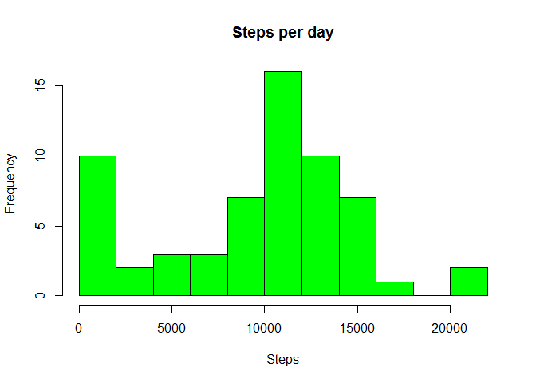

```r
dailysteps<-aggregate(
  steps ~ date,
  data = completeactivity,
  sum
)
hist(
  dailysteps$steps,
  main = "Steps per day",
  xlab = "Steps",
  col = "green",
  breaks = 8
)
```

```r
meanstepsdaily = mean(dailysteps$steps)
medianstepsdaily = mean(dailysteps$steps)
```

## Are there differences in activity patterns between weekdays and weekends?

> Create a new factor variable in the dataset with two levels – “weekday” and “weekend” indicating whether a given date is a weekday or weekend day.

```r
weekdaynames = c(
  "Monday",
  "Tuesday",
  "Wednesday",
  "Thursday",
  "Friday"
)
completeactivity$week <- factor(
  (
    weekdays(
      as.Date(completeactivity$date)
    ) %in% weekdaynames
  ),
  levels = c("TRUE", "FALSE"),
  labels = c("weekend", "weekday")
)

# add factors for sorting
completeactivity$week <- factor(
    completeactivity$week,
    levels=c(
        "weekday",
        "weekend"
    )
)
```

> Make a panel plot containing a time series plot (i.e. type = “l”) of the 5-minute interval (x-axis) and the average number of steps taken, averaged across all weekday days or weekend days (y-axis). See the README file in the GitHub repository to see an example of what this plot should look like using simulated data.

[figure not shown]

```r
stepsivalweek <- aggregate(
    steps ~ interval + week,
    completeactivity,
    mean
)
library(lattice)
xyplot(
    steps ~ interval | factor(week),
    data = stepsivalweek,
    col = "orange",
    aspect = 1/2,
    ylab = "Steps",
    xlab = "Interval",
    type = "l"
)
```